# 选读｜分布漂移：什么变了，什么没变？

本Notebook使用人为设定的概率分布，独立复现课件末尾三张概念图；不是UCI或digits实测，不训练新模型。蓝色实线为参考分布，橙色虚线为部署分布。X是提取的缺陷分数，Y=1为不合格。

```python
from pathlib import Path
import sys
import numpy as np
from IPython.display import display, Image, HTML
ROOT = next(p for p in [Path.cwd(), *Path.cwd().parents] if (p / "lessons/content-v3/06.json").exists())
LESSON = ROOT / "lessons/06-model-selection"
sys.path.insert(0, str(LESSON / "notebook/helpers"))
import shift_diagrams as plots
ASSETS = LESSON / "assets"
```

```
Matplotlib is building the font cache; this may take a moment.
```

```python
# 显示辅助：运行后正文、表格和print输出统一放大。
display(HTML("<style>.jp-RenderedHTMLCommon,.jp-RenderedMarkdown,.jp-OutputArea pre{font-size:20px!important;line-height:1.55!important}.jp-RenderedHTMLCommon table{font-size:20px!important}</style>"))
```

## 1｜协变量偏移：输入变化，条件关系不变

只改变输入分数的密度，给定分数的不合格概率保持不变。换设备不一定是这种纯机制。

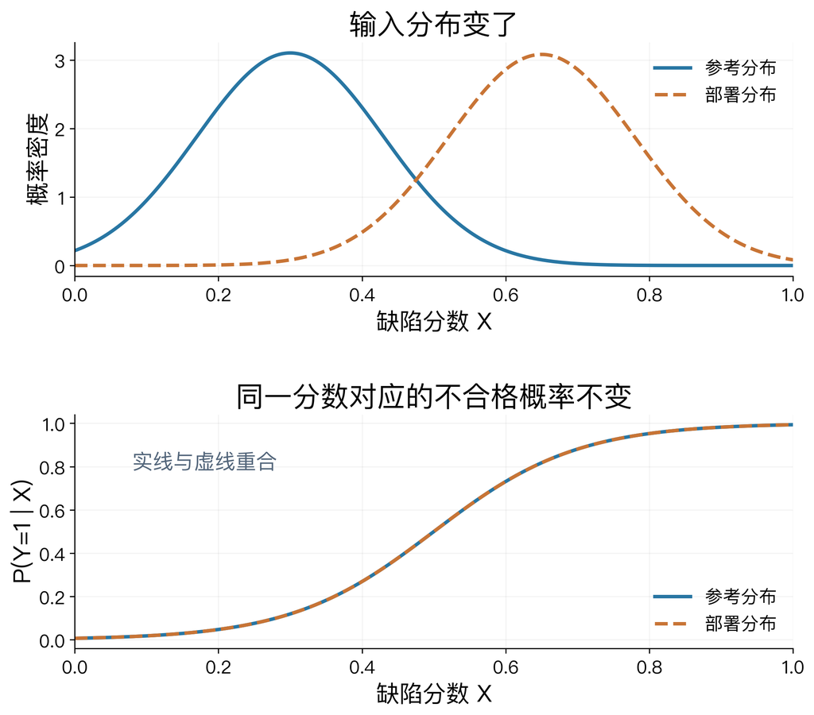

```python
x = np.linspace(0, 1, 501)
px_ref = plots.density(x, .30, .13)
px_dep = plots.density(x, .65, .13)
risk = plots.posterior(x, .50)
# 核对两个输入密度分别积分为1。
assert np.isclose(np.trapezoid(px_ref, x), 1) and np.isclose(np.trapezoid(px_dep, x), 1)
plots.covariate(x, px_ref, px_dep, risk, ASSETS / "l6-shift-covariate.svg")
display(Image(filename=str(ASSETS / "l6-shift-covariate.png")))
```

## 2｜类别先验偏移：比例变化，类内特征分布不变

两个类别的特征密度固定，只改变不合格率。注意：后验概率也可能随先验变化。

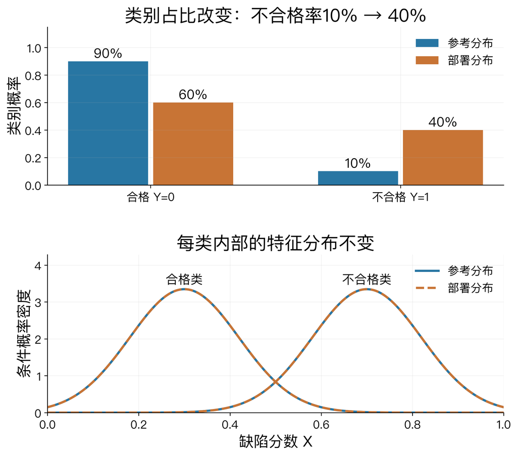

```
不合格率=10%，相同X=0.5时的不合格概率=10%
不合格率=40%，相同X=0.5时的不合格概率=40%
```

```python
class0 = plots.density(x, .30, .12)
class1 = plots.density(x, .70, .12)
priors = [.10, .40]
plots.label_shift(x, class0, class1, priors, ASSETS / "l6-shift-label.svg")
display(Image(filename=str(ASSETS / "l6-shift-label.png")))
for prior in priors:
    posterior = prior*class1 / ((1-prior)*class0 + prior*class1)
    print(f"不合格率={prior:.0%}，相同X=0.5时的不合格概率={posterior[250]:.0%}")
```

## 3｜概念漂移：条件关系变化，输入可以不变

把同一输入密度固定，只改变真实的标签概率函数。这里是概率机制示意，不是用数据训练了两次Logistic回归。

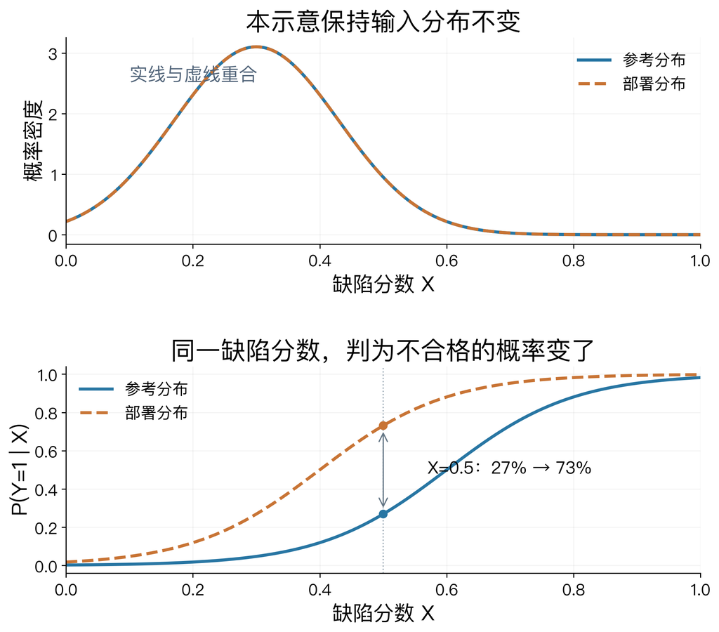

```
X=0.5：26.9% → 73.1%
```

```python
old_risk = plots.posterior(x, .60)
new_risk = plots.posterior(x, .40)
# X分布固定时，给定同一输入的标签概率仍可以不同。
assert old_risk[250] < new_risk[250]
plots.concept(x, px_ref, old_risk, new_risk, ASSETS / "l6-shift-concept.svg")
display(Image(filename=str(ASSETS / "l6-shift-concept.png")))
print(f"X=0.5：{old_risk[250]:.1%} → {new_risk[250]:.1%}")
```

## 阅读与术语边界

三种是理想化的分析方式，不是互斥穷尽分类。Label shift也能改变P(Y|X)；concept drift在部分文献中是更宽泛的上位词。域偏移描述环境差异，突发/渐进/周期漂移描述时间形态。仅看无标签输入一般不能识别所有条件关系变化。

- [MIT DCAI：Class Imbalance, Outliers, and Distribution Shift](https://dcai.csail.mit.edu/2023/imbalance-outliers-shift/)
- [D2L：Environment and Distribution Shift](https://d2l.ai/chapter_linear-classification/environment-and-distribution-shift.html)
- [Lipton等：Detecting and Correcting for Label Shift with Black Box Predictors](https://proceedings.mlr.press/v80/lipton18a.html)
- [Lu等：Learning under Concept Drift: A Review](https://arxiv.org/abs/2004.05785)
- [Koh等：WILDS](https://proceedings.mlr.press/v139/koh21a.html)

核查：2026-11-02。